# Risk Factor Analysis

## Outcome Variable

**Outcome Variable:** stunted

## Predictor Variables

**Intervention Variable:** safeh20

**Adjustment Set:**

- arm
- sex
- W_mage
- meducyrs
- feducyrs
- hhwealth_quart
- hfoodsec
- W_mhtcm
- W_mwtkg
- W_mbmi
- W_nrooms
- W_nchldlt5
- W_parity
- impfloor
- impsan
- delta_W_mage
- delta_meducyrs
- delta_feducyrs
- delta_hhwealth_quart
- delta_hfoodsec
- delta_W_mhtcm
- delta_W_mwtkg
- delta_W_mbmi
- delta_W_nrooms
- delta_W_nchldlt5
- delta_W_parity
- delta_impfloor
- delta_impsan

## Stratifying Variables

The analysis was stratified on these variable(s):

- agecat
- studyid
- country

## Data Summary

| agecat | studyid | country | safeh20 | stunted | n_cell | n |
| --- | --- | --- | --- | --- | --- | --- |
| Birth | ki0047075b-MAL-ED | BANGLADESH | 1 | 0 | 0 | 213 |
| Birth | ki0047075b-MAL-ED | BANGLADESH | 1 | 1 | 0 | 213 |
| Birth | ki0047075b-MAL-ED | BANGLADESH | 0 | 0 | 176 | 213 |
| Birth | ki0047075b-MAL-ED | BANGLADESH | 0 | 1 | 37 | 213 |
| Birth | ki0047075b-MAL-ED | BRAZIL | 1 | 0 | 0 | 41 |
| Birth | ki0047075b-MAL-ED | BRAZIL | 1 | 1 | 0 | 41 |
| Birth | ki0047075b-MAL-ED | BRAZIL | 0 | 0 | 32 | 41 |
| Birth | ki0047075b-MAL-ED | BRAZIL | 0 | 1 | 9 | 41 |
| Birth | ki0047075b-MAL-ED | INDIA | 1 | 0 | 0 | 41 |
| Birth | ki0047075b-MAL-ED | INDIA | 1 | 1 | 0 | 41 |
| Birth | ki0047075b-MAL-ED | INDIA | 0 | 0 | 33 | 41 |
| Birth | ki0047075b-MAL-ED | INDIA | 0 | 1 | 8 | 41 |
| Birth | ki0047075b-MAL-ED | NEPAL | 1 | 0 | 1 | 26 |
| Birth | ki0047075b-MAL-ED | NEPAL | 1 | 1 | 0 | 26 |
| Birth | ki0047075b-MAL-ED | NEPAL | 0 | 0 | 23 | 26 |
| Birth | ki0047075b-MAL-ED | NEPAL | 0 | 1 | 2 | 26 |
| Birth | ki0047075b-MAL-ED | PERU | 1 | 0 | 8 | 207 |
| Birth | ki0047075b-MAL-ED | PERU | 1 | 1 | 1 | 207 |
| Birth | ki0047075b-MAL-ED | PERU | 0 | 0 | 176 | 207 |
| Birth | ki0047075b-MAL-ED | PERU | 0 | 1 | 22 | 207 |
| Birth | ki0047075b-MAL-ED | SOUTH AFRICA | 1 | 0 | 12 | 96 |
| Birth | ki0047075b-MAL-ED | SOUTH AFRICA | 1 | 1 | 1 | 96 |
| Birth | ki0047075b-MAL-ED | SOUTH AFRICA | 0 | 0 | 76 | 96 |
| Birth | ki0047075b-MAL-ED | SOUTH AFRICA | 0 | 1 | 7 | 96 |
| Birth | ki0047075b-MAL-ED | TANZANIA, UNITED REPUBLIC OF | 1 | 0 | 68 | 119 |
| Birth | ki0047075b-MAL-ED | TANZANIA, UNITED REPUBLIC OF | 1 | 1 | 11 | 119 |
| Birth | ki0047075b-MAL-ED | TANZANIA, UNITED REPUBLIC OF | 0 | 0 | 30 | 119 |
| Birth | ki0047075b-MAL-ED | TANZANIA, UNITED REPUBLIC OF | 0 | 1 | 10 | 119 |
| Birth | ki1017093-NIH-Birth | BANGLADESH | 1 | 0 | 511 | 608 |
| Birth | ki1017093-NIH-Birth | BANGLADESH | 1 | 1 | 95 | 608 |

[output cut: 134 more lines]

The following strata were considered:

- agecat: 24 months, studyid: ki0047075b-MAL-ED, country: BANGLADESH
- agecat: 24 months, studyid: ki0047075b-MAL-ED, country: BRAZIL
- agecat: 24 months, studyid: ki0047075b-MAL-ED, country: INDIA
- agecat: 24 months, studyid: ki0047075b-MAL-ED, country: NEPAL
- agecat: 24 months, studyid: ki0047075b-MAL-ED, country: PERU
- agecat: 24 months, studyid: ki0047075b-MAL-ED, country: SOUTH AFRICA
- agecat: 24 months, studyid: ki0047075b-MAL-ED, country: TANZANIA, UNITED REPUBLIC OF
- agecat: 24 months, studyid: ki1017093-NIH-Birth, country: BANGLADESH
- agecat: 24 months, studyid: ki1017093b-PROVIDE, country: BANGLADESH
- agecat: 24 months, studyid: ki1017093c-NIH-Crypto, country: BANGLADESH
- agecat: 24 months, studyid: ki1114097-CONTENT, country: PERU
- agecat: 24 months, studyid: ki1148112-LCNI-5, country: MALAWI
- agecat: 24 months, studyid: kiGH5241-JiVitA-3, country: BANGLADESH
- agecat: 24 months, studyid: kiGH5241-JiVitA-4, country: BANGLADESH
- agecat: 6 months, studyid: ki0047075b-MAL-ED, country: BANGLADESH
- agecat: 6 months, studyid: ki0047075b-MAL-ED, country: BRAZIL
- agecat: 6 months, studyid: ki0047075b-MAL-ED, country: INDIA
- agecat: 6 months, studyid: ki0047075b-MAL-ED, country: NEPAL
- agecat: 6 months, studyid: ki0047075b-MAL-ED, country: PERU
- agecat: 6 months, studyid: ki0047075b-MAL-ED, country: SOUTH AFRICA
- agecat: 6 months, studyid: ki0047075b-MAL-ED, country: TANZANIA, UNITED REPUBLIC OF
- agecat: 6 months, studyid: ki1000304b-SAS-FoodSuppl, country: INDIA
- agecat: 6 months, studyid: ki1017093-NIH-Birth, country: BANGLADESH
- agecat: 6 months, studyid: ki1017093b-PROVIDE, country: BANGLADESH
- agecat: 6 months, studyid: ki1017093c-NIH-Crypto, country: BANGLADESH
- agecat: 6 months, studyid: ki1114097-CONTENT, country: PERU
- agecat: 6 months, studyid: ki1148112-LCNI-5, country: MALAWI
- agecat: 6 months, studyid: kiGH5241-JiVitA-3, country: BANGLADESH
- agecat: 6 months, studyid: kiGH5241-JiVitA-4, country: BANGLADESH
- agecat: Birth, studyid: ki0047075b-MAL-ED, country: BANGLADESH
- agecat: Birth, studyid: ki0047075b-MAL-ED, country: BRAZIL
- agecat: Birth, studyid: ki0047075b-MAL-ED, country: INDIA
- agecat: Birth, studyid: ki0047075b-MAL-ED, country: NEPAL
- agecat: Birth, studyid: ki0047075b-MAL-ED, country: PERU
- agecat: Birth, studyid: ki0047075b-MAL-ED, country: SOUTH AFRICA
- agecat: Birth, studyid: ki0047075b-MAL-ED, country: TANZANIA, UNITED REPUBLIC OF
- agecat: Birth, studyid: ki1017093-NIH-Birth, country: BANGLADESH
- agecat: Birth, studyid: ki1017093b-PROVIDE, country: BANGLADESH
- agecat: Birth, studyid: ki1017093c-NIH-Crypto, country: BANGLADESH
- agecat: Birth, studyid: kiGH5241-JiVitA-3, country: BANGLADESH
- agecat: Birth, studyid: kiGH5241-JiVitA-4, country: BANGLADESH

### Dropped Strata

Some strata were dropped due to rare outcomes:

- agecat: Birth, studyid: ki0047075b-MAL-ED, country: BANGLADESH
- agecat: Birth, studyid: ki0047075b-MAL-ED, country: BRAZIL
- agecat: Birth, studyid: ki0047075b-MAL-ED, country: INDIA
- agecat: Birth, studyid: ki0047075b-MAL-ED, country: NEPAL
- agecat: Birth, studyid: ki0047075b-MAL-ED, country: PERU
- agecat: Birth, studyid: ki0047075b-MAL-ED, country: SOUTH AFRICA
- agecat: Birth, studyid: ki1017093-NIH-Birth, country: BANGLADESH
- agecat: Birth, studyid: ki1017093b-PROVIDE, country: BANGLADESH
- agecat: Birth, studyid: ki1017093c-NIH-Crypto, country: BANGLADESH
- agecat: Birth, studyid: kiGH5241-JiVitA-4, country: BANGLADESH
- agecat: 6 months, studyid: ki0047075b-MAL-ED, country: BANGLADESH
- agecat: 6 months, studyid: ki0047075b-MAL-ED, country: BRAZIL
- agecat: 6 months, studyid: ki0047075b-MAL-ED, country: INDIA
- agecat: 6 months, studyid: ki0047075b-MAL-ED, country: NEPAL
- agecat: 6 months, studyid: ki0047075b-MAL-ED, country: PERU
- agecat: 6 months, studyid: ki1000304b-SAS-FoodSuppl, country: INDIA
- agecat: 6 months, studyid: ki1017093-NIH-Birth, country: BANGLADESH
- agecat: 6 months, studyid: ki1017093b-PROVIDE, country: BANGLADESH
- agecat: 6 months, studyid: ki1017093c-NIH-Crypto, country: BANGLADESH
- agecat: 6 months, studyid: ki1114097-CONTENT, country: PERU
- agecat: 6 months, studyid: kiGH5241-JiVitA-4, country: BANGLADESH
- agecat: 24 months, studyid: ki0047075b-MAL-ED, country: BANGLADESH
- agecat: 24 months, studyid: ki0047075b-MAL-ED, country: BRAZIL
- agecat: 24 months, studyid: ki0047075b-MAL-ED, country: INDIA
- agecat: 24 months, studyid: ki0047075b-MAL-ED, country: NEPAL
- agecat: 24 months, studyid: ki0047075b-MAL-ED, country: PERU
- agecat: 24 months, studyid: ki1017093-NIH-Birth, country: BANGLADESH
- agecat: 24 months, studyid: ki1017093b-PROVIDE, country: BANGLADESH
- agecat: 24 months, studyid: ki1017093c-NIH-Crypto, country: BANGLADESH
- agecat: 24 months, studyid: ki1114097-CONTENT, country: PERU
- agecat: 24 months, studyid: kiGH5241-JiVitA-3, country: BANGLADESH
- agecat: 24 months, studyid: kiGH5241-JiVitA-4, country: BANGLADESH

## Methods Detail

We’re interested in the causal parameters $E[Y_a]$ for all values of $a \in \mathcal{A}$. These parameters represent the mean outcome if, possibly contrary to fact, we intervened to set all units to have $A=a$. Under the randomization and positivity assumptions, these are identified by the statistical parameters $\psi_a=E_W[E_{Y|A,W}(Y|A=a,W)]$. In addition, we’re interested in the mean of $Y$, $E[Y]$ under no intervention (the observed mean). We will estimate these parameters by using SuperLearner to fit the relevant likelihood factors – $E_{Y|A,W}(Y|A=a,W)$ and $p(A=a|W)$, and then updating our likelihood fit using a joint TMLE.

For unadjusted analyses ($W=\{\}$), initial likelihoods were estimated using Lrnr_glm to estimate the simple $E(Y|A)$ and Lrnr_mean to estimate $p(A)$. For adjusted analyses, a small library containing Lrnr_glmnet, Lrnr_xgboost, and Lrnr_mean was used.

Having estimated these parameters, we will then use the delta method to estimate relative risks and attributable risks relative to a prespecified baseline level of $A$.

# Results Detail

## Results Plots

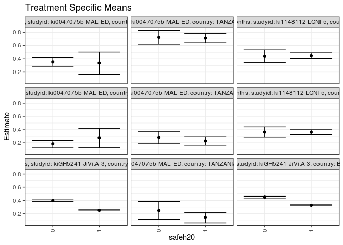

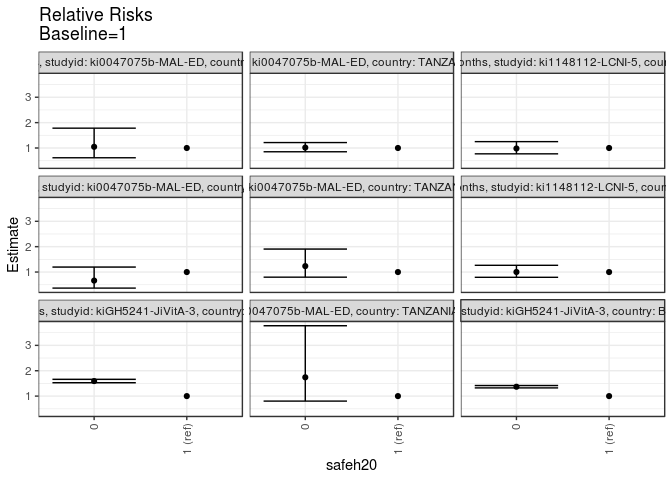

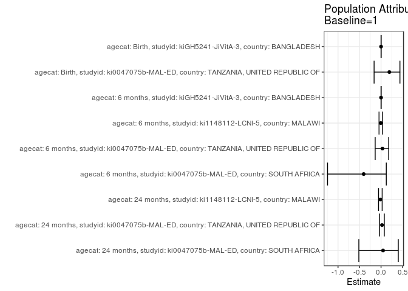

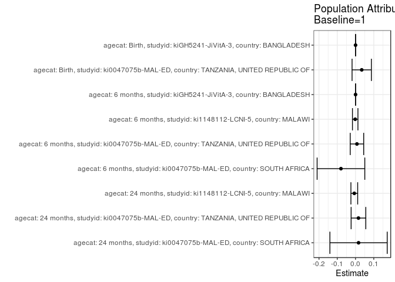

## Results Table

### Parameter: TSM

| agecat | studyid | country | intervention_level | baseline_level | estimate | ci_lower | ci_upper |
| --- | --- | --- | --- | --- | --- | --- | --- |
| Birth | ki0047075b-MAL-ED | TANZANIA, UNITED REPUBLIC OF | 1 | NA | 0.1423857 | 0.0647022 | 0.2200693 |
| Birth | ki0047075b-MAL-ED | TANZANIA, UNITED REPUBLIC OF | 0 | NA | 0.2478489 | 0.1105183 | 0.3851796 |
| Birth | kiGH5241-JiVitA-3 | BANGLADESH | 1 | NA | 0.3288723 | 0.3213301 | 0.3364144 |
| Birth | kiGH5241-JiVitA-3 | BANGLADESH | 0 | NA | 0.4501564 | 0.4382113 | 0.4621016 |
| 6 months | ki0047075b-MAL-ED | SOUTH AFRICA | 1 | NA | 0.2773152 | 0.1329924 | 0.4216379 |
| 6 months | ki0047075b-MAL-ED | SOUTH AFRICA | 0 | NA | 0.1839600 | 0.1315755 | 0.2363446 |
| 6 months | ki0047075b-MAL-ED | TANZANIA, UNITED REPUBLIC OF | 1 | NA | 0.2279077 | 0.1645328 | 0.2912826 |
| 6 months | ki0047075b-MAL-ED | TANZANIA, UNITED REPUBLIC OF | 0 | NA | 0.2812609 | 0.1858048 | 0.3767169 |
| 6 months | ki1148112-LCNI-5 | MALAWI | 1 | NA | 0.3644810 | 0.3283128 | 0.4006493 |
| 6 months | ki1148112-LCNI-5 | MALAWI | 0 | NA | 0.3651979 | 0.2870925 | 0.4433034 |
| 6 months | kiGH5241-JiVitA-3 | BANGLADESH | 1 | NA | 0.2512066 | 0.2428938 | 0.2595194 |
| 6 months | kiGH5241-JiVitA-3 | BANGLADESH | 0 | NA | 0.4000000 | 0.3887912 | 0.4112088 |
| 24 months | ki0047075b-MAL-ED | SOUTH AFRICA | 1 | NA | 0.3377639 | 0.1700691 | 0.5054587 |
| 24 months | ki0047075b-MAL-ED | SOUTH AFRICA | 0 | NA | 0.3537516 | 0.2875106 | 0.4199927 |
| 24 months | ki0047075b-MAL-ED | TANZANIA, UNITED REPUBLIC OF | 1 | NA | 0.7115421 | 0.6389081 | 0.7841761 |
| 24 months | ki0047075b-MAL-ED | TANZANIA, UNITED REPUBLIC OF | 0 | NA | 0.7236820 | 0.6177806 | 0.8295835 |
| 24 months | ki1148112-LCNI-5 | MALAWI | 1 | NA | 0.4491667 | 0.4045708 | 0.4937627 |
| 24 months | ki1148112-LCNI-5 | MALAWI | 0 | NA | 0.4407085 | 0.3427900 | 0.5386270 |

### Parameter: E(Y)

| agecat | studyid | country | intervention_level | baseline_level | estimate | ci_lower | ci_upper |
| --- | --- | --- | --- | --- | --- | --- | --- |
| Birth | ki0047075b-MAL-ED | TANZANIA, UNITED REPUBLIC OF | NA | NA | 0.1764706 | 0.1076873 | 0.2452539 |
| Birth | kiGH5241-JiVitA-3 | BANGLADESH | NA | NA | 0.3290835 | 0.3217078 | 0.3364591 |
| 6 months | ki0047075b-MAL-ED | SOUTH AFRICA | NA | NA | 0.1975806 | 0.1479246 | 0.2472367 |
| 6 months | ki0047075b-MAL-ED | TANZANIA, UNITED REPUBLIC OF | NA | NA | 0.2357724 | 0.1826200 | 0.2889248 |
| 6 months | ki1148112-LCNI-5 | MALAWI | NA | NA | 0.3627451 | 0.3297365 | 0.3957537 |
| 6 months | kiGH5241-JiVitA-3 | BANGLADESH | NA | NA | 0.2513837 | 0.2432545 | 0.2595129 |
| 24 months | ki0047075b-MAL-ED | SOUTH AFRICA | NA | NA | 0.3544304 | 0.2934024 | 0.4154584 |
| 24 months | ki0047075b-MAL-ED | TANZANIA, UNITED REPUBLIC OF | NA | NA | 0.7276995 | 0.6677783 | 0.7876207 |
| 24 months | ki1148112-LCNI-5 | MALAWI | NA | NA | 0.4425087 | 0.4018409 | 0.4831765 |

### Parameter: RR

| agecat | studyid | country | intervention_level | baseline_level | estimate | ci_lower | ci_upper |
| --- | --- | --- | --- | --- | --- | --- | --- |
| Birth | ki0047075b-MAL-ED | TANZANIA, UNITED REPUBLIC OF | 1 | 1 | 1.0000000 | 1.0000000 | 1.000000 |
| Birth | ki0047075b-MAL-ED | TANZANIA, UNITED REPUBLIC OF | 0 | 1 | 1.7406865 | 0.8030201 | 3.773243 |
| Birth | kiGH5241-JiVitA-3 | BANGLADESH | 1 | 1 | 1.0000000 | 1.0000000 | 1.000000 |
| Birth | kiGH5241-JiVitA-3 | BANGLADESH | 0 | 1 | 1.3687880 | 1.3228025 | 1.416372 |
| 6 months | ki0047075b-MAL-ED | SOUTH AFRICA | 1 | 1 | 1.0000000 | 1.0000000 | 1.000000 |
| 6 months | ki0047075b-MAL-ED | SOUTH AFRICA | 0 | 1 | 0.6633609 | 0.3677205 | 1.196691 |
| 6 months | ki0047075b-MAL-ED | TANZANIA, UNITED REPUBLIC OF | 1 | 1 | 1.0000000 | 1.0000000 | 1.000000 |
| 6 months | ki0047075b-MAL-ED | TANZANIA, UNITED REPUBLIC OF | 0 | 1 | 1.2340998 | 0.7990330 | 1.906057 |
| 6 months | ki1148112-LCNI-5 | MALAWI | 1 | 1 | 1.0000000 | 1.0000000 | 1.000000 |
| 6 months | ki1148112-LCNI-5 | MALAWI | 0 | 1 | 1.0019668 | 0.7930393 | 1.265937 |
| 6 months | kiGH5241-JiVitA-3 | BANGLADESH | 1 | 1 | 1.0000000 | 1.0000000 | 1.000000 |
| 6 months | kiGH5241-JiVitA-3 | BANGLADESH | 0 | 1 | 1.5923150 | 1.5266883 | 1.660763 |
| 24 months | ki0047075b-MAL-ED | SOUTH AFRICA | 1 | 1 | 1.0000000 | 1.0000000 | 1.000000 |
| 24 months | ki0047075b-MAL-ED | SOUTH AFRICA | 0 | 1 | 1.0473339 | 0.6156041 | 1.781840 |
| 24 months | ki0047075b-MAL-ED | TANZANIA, UNITED REPUBLIC OF | 1 | 1 | 1.0000000 | 1.0000000 | 1.000000 |
| 24 months | ki0047075b-MAL-ED | TANZANIA, UNITED REPUBLIC OF | 0 | 1 | 1.0170614 | 0.8520260 | 1.214064 |
| 24 months | ki1148112-LCNI-5 | MALAWI | 1 | 1 | 1.0000000 | 1.0000000 | 1.000000 |
| 24 months | ki1148112-LCNI-5 | MALAWI | 0 | 1 | 0.9811690 | 0.7697780 | 1.250611 |

### Parameter: PAR

| agecat | studyid | country | intervention_level | baseline_level | estimate | ci_lower | ci_upper |
| --- | --- | --- | --- | --- | --- | --- | --- |
| Birth | ki0047075b-MAL-ED | TANZANIA, UNITED REPUBLIC OF | 1 | NA | 0.0340848 | -0.0188693 | 0.0870390 |
| Birth | kiGH5241-JiVitA-3 | BANGLADESH | 1 | NA | 0.0002112 | -0.0001288 | 0.0005512 |
| 6 months | ki0047075b-MAL-ED | SOUTH AFRICA | 1 | NA | -0.0797345 | -0.2103040 | 0.0508349 |
| 6 months | ki0047075b-MAL-ED | TANZANIA, UNITED REPUBLIC OF | 1 | NA | 0.0078646 | -0.0289767 | 0.0447060 |
| 6 months | ki1148112-LCNI-5 | MALAWI | 1 | NA | -0.0017359 | -0.0167458 | 0.0132739 |
| 6 months | kiGH5241-JiVitA-3 | BANGLADESH | 1 | NA | 0.0001771 | -0.0001696 | 0.0005239 |
| 24 months | ki0047075b-MAL-ED | SOUTH AFRICA | 1 | NA | 0.0166664 | -0.1402367 | 0.1735695 |
| 24 months | ki0047075b-MAL-ED | TANZANIA, UNITED REPUBLIC OF | 1 | NA | 0.0161574 | -0.0240479 | 0.0563628 |
| 24 months | ki1148112-LCNI-5 | MALAWI | 1 | NA | -0.0066580 | -0.0251764 | 0.0118603 |

### Parameter: PAF

| agecat | studyid | country | intervention_level | baseline_level | estimate | ci_lower | ci_upper |
| --- | --- | --- | --- | --- | --- | --- | --- |
| Birth | ki0047075b-MAL-ED | TANZANIA, UNITED REPUBLIC OF | 1 | NA | 0.1931474 | -0.1614848 | 0.4395010 |
| Birth | kiGH5241-JiVitA-3 | BANGLADESH | 1 | NA | 0.0006418 | -0.0003987 | 0.0016812 |
| 6 months | ki0047075b-MAL-ED | SOUTH AFRICA | 1 | NA | -0.4035543 | -1.2435423 | 0.1219400 |
| 6 months | ki0047075b-MAL-ED | TANZANIA, UNITED REPUBLIC OF | 1 | NA | 0.0333569 | -0.1360776 | 0.1775219 |
| 6 months | ki1148112-LCNI-5 | MALAWI | 1 | NA | -0.0047856 | -0.0470335 | 0.0357576 |
| 6 months | kiGH5241-JiVitA-3 | BANGLADESH | 1 | NA | 0.0007045 | -0.0006877 | 0.0020948 |
| 24 months | ki0047075b-MAL-ED | SOUTH AFRICA | 1 | NA | 0.0470232 | -0.5164159 | 0.4011110 |
| 24 months | ki0047075b-MAL-ED | TANZANIA, UNITED REPUBLIC OF | 1 | NA | 0.0222034 | -0.0346968 | 0.0759746 |
| 24 months | ki1148112-LCNI-5 | MALAWI | 1 | NA | -0.0150461 | -0.0578008 | 0.0259805 |